# Problem Set 2 — Solutions

Econ 122

2026-10-03

```r
library(tidyverse)
library(lubridate)
```

```r
sales <- read_csv("ps2_sales_data.csv")
glimpse(sales)
```

```
## Rows: 600
## Columns: 6
## $ order_id         <chr> "ORD-12681", "ORD-51006", "ORD-75718", "ORD-49102", "…
## $ region           <chr> "West", "Northeast", "Midwest", "Northeast", "West", …
## $ sale_date        <chr> "February 08 2025", "06/23/2024", "06/05/2024", "2024…
## $ marketing_spend  <dbl> 240.10, 233.97, 156.28, 152.49, 198.99, 214.74, 191.0…
## $ units_sold       <dbl> 2690, 4618, 1780, 3609, 2655, 2438, 1549, 1551, 2558,…
## $ product_category <chr> "Gadget C", "Gadget B", "Gadget A", "Gadget-B", "Gadg…
```

Notice that `sale_date` reads in as **character**, not a date. That’s the problem Q1.2 asks you to fix.

# Part 1

## Question 1.1 — Inconsistent text

```r
# before
sales %>% count(product_category, sort = TRUE)
```

```
## # A tibble: 9 × 2
##   product_category     n
##   <chr>            <int>
## 1 Gadget A           210
## 2 Gadget B           187
## 3 Gadget C            93
## 4 Gadget-B            55
## 5 Gadget-A            51
## 6 GADGET B             1
## 7 Gadget-c             1
## 8 gadget a             1
## 9 gadget-B             1
```

```r
# after: trim whitespace, normalise separators, fix capitalisation
sales <- sales %>%
  mutate(product_category = str_to_title(
           str_replace_all(str_trim(product_category), "-", " ")))

sales %>% count(product_category, sort = TRUE)
```

```
## # A tibble: 3 × 2
##   product_category     n
##   <chr>            <int>
## 1 Gadget A           262
## 2 Gadget B           244
## 3 Gadget C            94
```

**Expected:** **9** distinct values collapse to **3** real categories (Gadget A / B / C).

The four messiest spellings (`gadget a`, `gadget-B`, `GADGET B`, `Gadget-c`) each appear **exactly once**, against hundreds for the clean spellings — the signature of hand-entered data. (`read_csv()` trims leading and trailing spaces by default, so stray whitespace never reaches you here — but `str_trim()` is still a good habit for data read other ways.)

**A common near-miss:** `str_to_title()` on its own leaves `Gadget-A`, `Gadget-B`, and `Gadget-C` separate from their spaced versions, giving **6** categories instead of 3 — you have to deal with the separators as well as the capitalization. Any route that gets to 3 is fine.

**Short answer — why an uncleaned model is misled.** The model treats `Gadget-A` and `Gadget A` as different products, so it splits one product’s evidence across several categories. Each fragment has a tiny sample, so estimates for them are noisy and unstable — and a category seen once in training may not appear at all at prediction time. Concretely: the mean of a one-row category is that single row, so a lone extreme order becomes an entire “product line’s” expected sales.

## Question 1.2 — Dates

```r
# what the formats look like
sales %>% slice(1:8) %>% pull(sale_date)
```

```
## [1] "February 08 2025" "06/23/2024"       "06/05/2024"       "2024-11-03"
## [5] "Mar 02, 2024"     "10/12/2024"       "Jul 02, 2024"     "February 19 2024"
```

```r
sales <- sales %>%
  mutate(sale_date_parsed = as_date(parse_date_time(
           sale_date, orders = c("ymd", "mdy", "dmy"))),
         sale_month       = month(sale_date_parsed),
         sale_day_of_week = wday(sale_date_parsed, label = TRUE, abbr = FALSE))

# did anything fail?
sum(is.na(sales$sale_date_parsed))
```

```
## [1] 0
```

```r
# check parsed values against the originals
sales %>% select(sale_date, sale_date_parsed) %>% slice(1:8)
```

```
## # A tibble: 8 × 2
##   sale_date        sale_date_parsed
##   <chr>            <date>
## 1 February 08 2025 2025-02-08
## 2 06/23/2024       2024-06-23
## 3 06/05/2024       2024-06-05
## 4 2024-11-03       2024-11-03
## 5 Mar 02, 2024     2024-03-02
## 6 10/12/2024       2024-10-12
## 7 Jul 02, 2024     2024-07-02
## 8 February 19 2024 2024-02-19
```

**Expected: four formats** — `2024-03-25`, `Mar 25, 2024`, `March 25 2024`, `03/25/2024` (roughly 140-170 rows each), and **0 failures**.

```r
sales %>% count(format = case_when(
  str_detect(sale_date, "^[0-9]{4}-")        ~ "ISO (2024-03-25)",
  str_detect(sale_date, "^[A-Za-z]{3} [0-9]")~ "Mar 25, 2024",
  str_detect(sale_date, "^[A-Za-z]{4,}")     ~ "March 25 2024",
  str_detect(sale_date, "/")                 ~ "03/25/2024"))
```

```
## # A tibble: 4 × 2
##   format               n
##   <chr>            <int>
## 1 03/25/2024         150
## 2 ISO (2024-03-25)   140
## 3 Mar 25, 2024       171
## 4 March 25 2024      139
```

**Why the eyeball check matters.** Counting `NA`s is not enough. A date that parses to the *wrong* day is still a date, so it raises no error and no warning — `parse_date_time()` is known to misread some formats (`25-Mar-2024` is a classic troublemaker) when a column mixes several. Here all 600 rows happen to parse correctly, but that is something you confirm by looking, not something you assume.

One detail: `wday(label = TRUE)` on its own returns “Mon”. You need `abbr = FALSE` to get “Monday”.

## Question 1.3 — Marketing spend

```r
summary(sales$marketing_spend)
```

```
##    Min. 1st Qu.  Median    Mean 3rd Qu.    Max.
##  -999.0   163.8   195.0   188.6   232.3   399.1
```

```r
sales %>% filter(marketing_spend < 0)
```

```
## # A tibble: 6 × 9
##   order_id  region    sale_date      marketing_spend units_sold product_category
##   <chr>     <chr>     <chr>                    <dbl>      <dbl> <chr>
## 1 ORD-66467 Midwest   September 02 …            -999       1695 Gadget A
## 2 ORD-40487 Midwest   January 31 20…            -999       1890 Gadget A
## 3 ORD-78390 Northeast Apr 27, 2024              -999       4428 Gadget B
## 4 ORD-39715 West      Sep 09, 2024              -999       1570 Gadget A
## 5 ORD-12343 Midwest   Mar 08, 2024              -999       1609 Gadget A
## 6 ORD-86815 Northeast May 18 2025               -999       5143 Gadget B
## # ℹ 3 more variables: sale_date_parsed <date>, sale_month <dbl>,
## #   sale_day_of_week <ord>
```

```r
mean_before <- mean(sales$marketing_spend)

sales <- sales %>% mutate(marketing_spend = na_if(marketing_spend, -999))

c(before = mean_before,
  after  = mean(sales$marketing_spend, na.rm = TRUE),
  n_missing = sum(is.na(sales$marketing_spend)))
```

```
##    before     after n_missing
##  188.6110  200.6071    6.0000
```

**Expected:** **6 rows** hold `-999`, a sentinel for missing. The mean moves from about **188.61** to **200.61** — roughly **$12**, or 6%.

The danger is that `-999` is a valid number, so `mean()` runs without complaint and returns a plausible-looking figure. An explicit `NA` would at least have forced `na.rm = TRUE` and made the decision visible.

# Part 2

## Question 2.1 — Does marketing work equally everywhere?

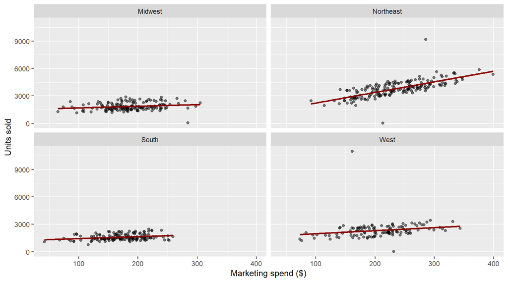

```r
ggplot(sales, aes(marketing_spend, units_sold)) +
  geom_point(alpha = 0.5) +
  geom_smooth(method = "lm", se = FALSE, color = "darkred") +
  facet_wrap(~ region) +
  labs(x = "Marketing spend ($)", y = "Units sold")
```

```r
sales %>% filter(!is.na(marketing_spend)) %>%
  group_by(region) %>%
  summarise(n = n(),
            slope = round(coef(lm(units_sold ~ marketing_spend))[2], 2))
```

```
## # A tibble: 4 × 3
##   region        n slope
##   <chr>     <int> <dbl>
## 1 Midwest     154  1.79
## 2 Northeast   177 11.6
## 3 South       145  2.14
## 4 West        118  3.32
```

**Expected:** **Northeast** is far and away the most effective at roughly **11.6** extra units per marketing dollar. Midwest is weakest at about **1.8** — so Northeast is roughly **6x** stronger.

## Question 2.2 — A weekly pattern

```r
sales %>% group_by(sale_day_of_week) %>%
  summarise(n = n(), avg_units = round(mean(units_sold)))
```

```
## # A tibble: 7 × 3
##   sale_day_of_week     n avg_units
##   <ord>            <int>     <dbl>
## 1 Sunday             110      2978
## 2 Monday              90      2354
## 3 Tuesday             69      2066
## 4 Wednesday           71      2301
## 5 Thursday            73      2125
## 6 Friday              87      2004
## 7 Saturday           100      3052
```

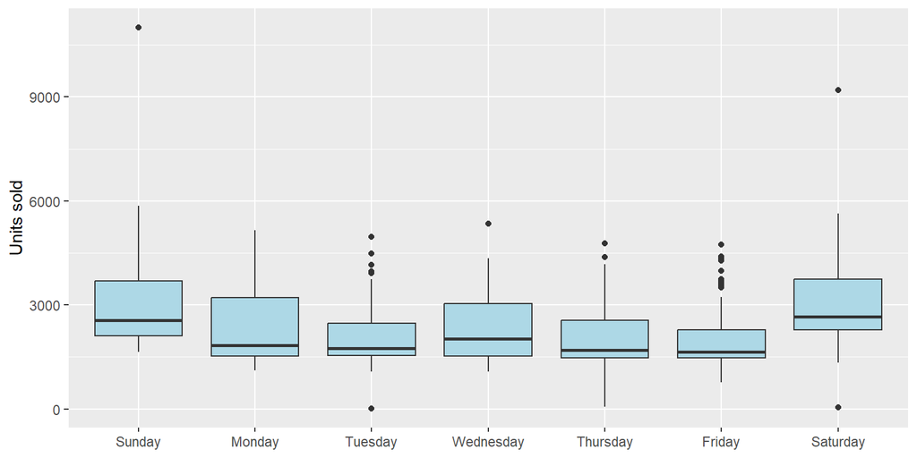

```r
ggplot(sales, aes(sale_day_of_week, units_sold)) +
  geom_boxplot(fill = "lightblue") +
  labs(x = NULL, y = "Units sold")
```

**Expected:** Saturday (~3,052) and Sunday (~2,978) sit well above the weekdays (~2,004–2,354). The weekend boxes are visibly higher.

Also notice the two extreme points — a Sunday near 11,000 and a Saturday near 9,200 — which lead into Q2.3.

`wday(label = TRUE)` returns an **ordered factor**, so the days plot in calendar order automatically.

## Question 2.3 — Outliers, two ways

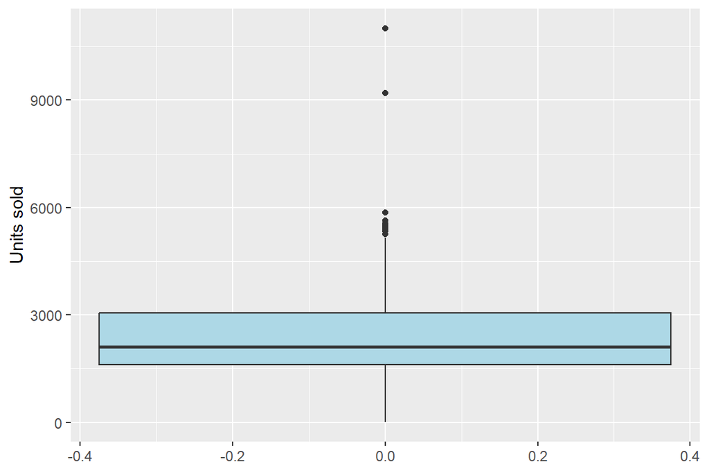

```r
ggplot(sales, aes(y = units_sold)) + geom_boxplot(fill = "lightblue") +
  labs(y = "Units sold")
```

```r
Q1 <- quantile(sales$units_sold, 0.25)
Q3 <- quantile(sales$units_sold, 0.75)
IQR_val <- Q3 - Q1

iqr_out <- sales %>% filter(units_sold < Q1 - 1.5 * IQR_val |
                            units_sold > Q3 + 1.5 * IQR_val)
z_out <- sales %>% mutate(z = as.numeric(scale(units_sold))) %>% filter(abs(z) > 3)

c(IQR_rule = nrow(iqr_out), z_rule = nrow(z_out))
```

```
## IQR_rule   z_rule
##        9        2
```

```r
iqr_out %>% select(order_id, region, sale_date, units_sold) %>% arrange(units_sold)
```

```
## # A tibble: 9 × 4
##   order_id  region    sale_date        units_sold
##   <chr>     <chr>     <chr>                 <dbl>
## 1 ORD-96467 Northeast 05/04/2025             5265
## 2 ORD-14321 Northeast May 14 2025            5350
## 3 ORD-46249 Northeast 04/19/2025             5416
## 4 ORD-17721 Northeast November 09 2024       5486
## 5 ORD-68356 Northeast 04/21/2024             5548
## 6 ORD-43176 Northeast January 20 2024        5640
## 7 ORD-46080 Northeast Jun 08, 2025           5867
## 8 ORD-85120 Northeast 11/30/2024             9200
## 9 ORD-52217 West      March 17 2024         11000
```

**Expected:** the IQR rule flags **9**, the z-score rule flags **2**.

**Short answer.** They disagree because the extreme values inflate the standard deviation that the z-score is measured against, so all but the most extreme points fall inside 3 SD. The IQR rule rests on quartiles and is unaffected by how far the outliers stretch.

Look at the rows. Only **2** of the 9 IQR flags are implausible as real orders (9,200 and 11,000 units — about double anything else in the data). The other 7 (roughly 5,300–5,900 units) are genuine high-volume orders: all from the Northeast, with high marketing spend, and mostly on weekends. They are exactly what Q2.1 and Q2.2 predict, so they must be kept — they are the pattern Parts 3 and 4 are built on. The two implausible values are worth investigating with whoever owns the data, and if you drop them, **say so**.

Both rules also **miss** something: three orders of 15, 40, and 60 units, far below anything else in the data. The IQR lower bound is negative (about −570), so no positive count can fall below it, and neither rule flags them. Outlier rules only look for values far from the center; a value can be wrong without being extreme. Sorting the column and looking at both ends catches these.

```r
sales %>% arrange(units_sold) %>%
  select(order_id, region, sale_date, units_sold) %>% head(5)
```

```
## # A tibble: 5 × 4
##   order_id  region    sale_date        units_sold
##   <chr>     <chr>     <chr>                 <dbl>
## 1 ORD-20701 West      February 20 2024         15
## 2 ORD-37395 Northeast 02/10/2024               40
## 3 ORD-12856 Midwest   April 10 2025            60
## 4 ORD-97711 South     04/25/2025              761
## 5 ORD-83614 South     Sep 04, 2024           1079
```

# Part 3

## Question 3.1 — Turn the pattern into a variable

```r
sales <- sales %>%
  mutate(is_weekend = if_else(wday(sale_date_parsed) %in% c(1, 7), 1, 0))
```

Any equivalent works: `%in% c("Saturday", "Sunday")` on the day-name column, `TRUE`/`FALSE` instead of 1/0, and so on.

## Question 3.2 — Does it separate the data?

```r
sales %>% group_by(is_weekend) %>%
  summarise(n = n(), avg_units = round(mean(units_sold)))
```

```
## # A tibble: 2 × 3
##   is_weekend     n avg_units
##        <dbl> <int>     <dbl>
## 1          0   390      2172
## 2          1   210      3013
```

**Expected:** weekday **n = 390, ~2,172** units; weekend **n = 210, ~3,013** — a gap of about **840 units**, or **39%**.

**Short answer.** `sale_date` is a near-unique identifier — hundreds of distinct values, each with a handful of rows — so a model can’t generalise from it. The binary variable states the pattern directly in a form the model can use, and it extends to dates never seen in training. It encodes *domain knowledge* (that weekends differ) rather than making the model rediscover it.

# Part 4

## Question 4.1 — Build and evaluate an interaction

```r
sales_c <- sales %>%
  filter(!is.na(marketing_spend)) %>%
  mutate(northeast = if_else(region == "Northeast", 1, 0),
         spend_x_northeast = marketing_spend * northeast)

c(spend_alone = round(cor(sales_c$marketing_spend, sales_c$units_sold), 3),
  interaction = round(cor(sales_c$spend_x_northeast, sales_c$units_sold), 3))
```

```
## spend_alone interaction
##       0.572       0.808
```

**Expected:** about **0.572** for `marketing_spend` alone versus **0.808** for the interaction — a gain of roughly **0.24**.

**Short answer.** Feature engineering creates **no new information**; every value came from two columns already present. What it does is put the information in a form the model can use. A single `marketing_spend` coefficient must compromise between a region where spend returns ~11.6 units and regions where it returns ~2–3. The interaction lets the relationship differ by group, so the strong Northeast effect stops being averaged away.

# Part 5

## Question 5 — Synthesis

A strong answer names three actionable findings and one honest caveat.

**Findings (any three):**

- Marketing is far more effective in the **Northeast** (~11.6 units per dollar) than elsewhere (~2–3) — reallocating budget is the clearest lever.
- **Weekend orders run ~39% larger** than weekday orders.
- **6 records** had missing marketing spend hidden as `-999`, and five unit counts are implausible (two far too high, three far too low) — the reporting pipeline needs fixing.
- The product catalogue is **3 products, not 9**; category entry is inconsistent.

**Caveats (any one):** this is observational data, so none of it is causal — the Northeast may differ in ways we haven’t measured. Slopes are estimated from a few hundred rows per region. The extreme values still influence the regional slopes. And weekend “effectiveness” may reflect which customers order when, not the day itself.